# Assignment 4

## Finding 3

This plot is trying to examine what are the balances and ages of people who default on their loans from the bank. In general, the trend shows that the customers with very low or negative balances end up defaulting as expected. As for the age criterion, there seems to be no correlation between the age and default.

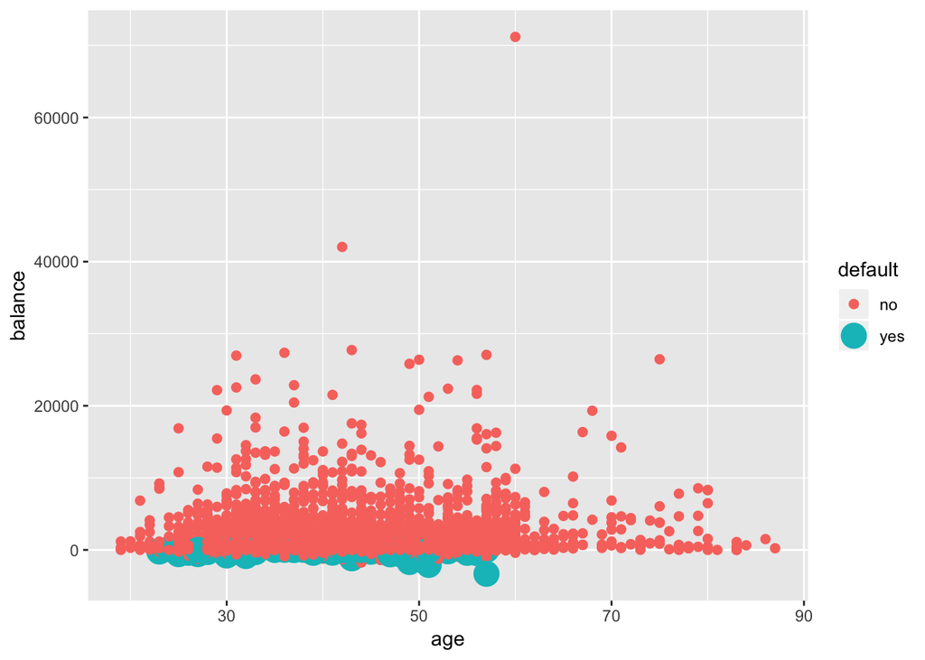

```r
ggplot(bank) + geom_point(aes(age, balance, color=default, size=default))
```

## Finding 4

This plot shows us the division of eduation for each job. As expected, *management* has the largest proportion of people having received *tertiary* education. On the other hand, *housemaid* is the group with the largest number of people having received *primary* education. These observations were as expected.

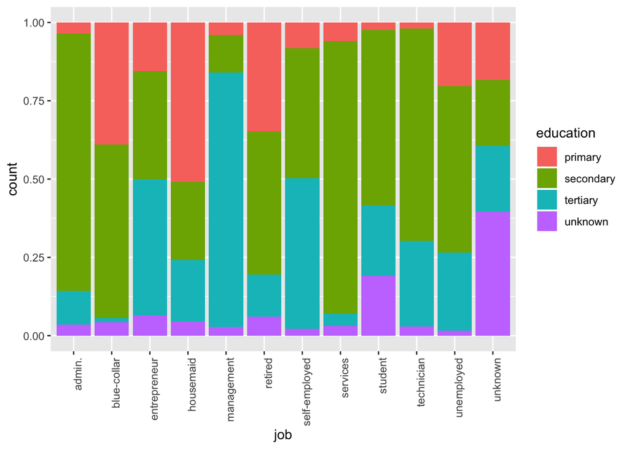

```r
ggplot(bank) +geom_bar(mapping = aes(x = job, fill = education),position = "fill") +
  theme(axis.text.x = element_text(angle = 90, hjust = 1))
```

## Finding 5

This plot is showing the percentage of people who default depending on their marital status. As expected the largest percentage of defaults are from divorced people.

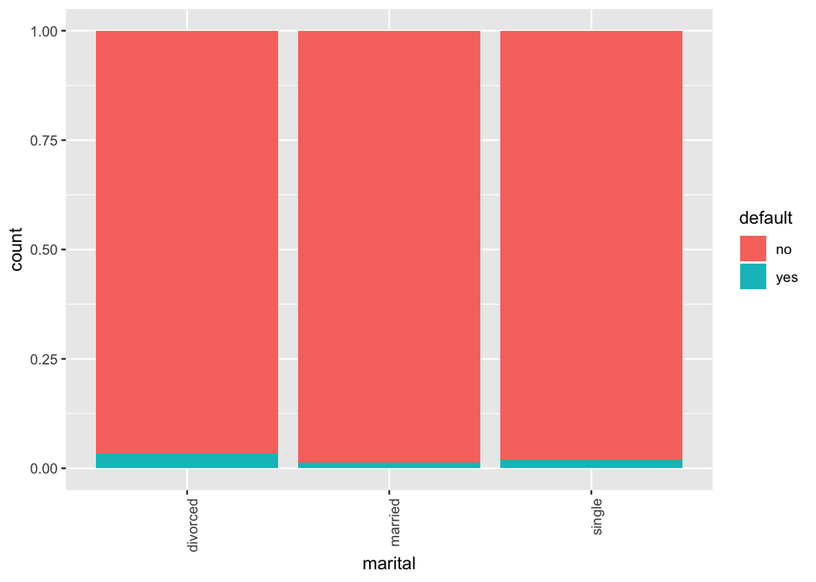

```r
ggplot(bank) +
  geom_bar(mapping = aes(x = marital, fill = default),position = "fill") +
  theme(axis.text.x = element_text(angle = 90, hjust = 1))
```

## Finding 6

This plot looks at a number of people with loans who default for each job. We can clearly see that the largest number of total defaults seems to be occuring in the group of people having only a housing loan. Technicians seem to default the most without any loans, whereas the number of defaults for those having only a houseing loan is largest for *management* and *blue-collar*.

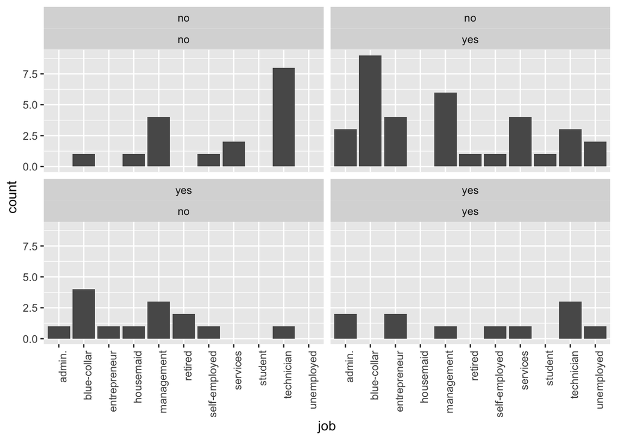

```r
ggplot(data = bank) +
  geom_bar(data = bank %>% dplyr::filter(default=='yes'), aes(x = job)) +
  facet_wrap(loan ~ housing, nrow = 2) +
  theme(axis.text.x = element_text(angle = 90, hjust = 1))
```